# BCB420 - A1

Mit Patel

### Dataset Information

**Publication Title:** Transcriptomic analyses reveal rhythmic and CLOCK-driven pathways in human skeletal muscle

**Publication Date:** 2018-04-16

**Publication Journal:** eLife

**GEO ID:** GSE108539

The dataset has intronic and extronic regions for each sample. The groups were defined as per the following definitions [1]:  
(1) Exonic: if it occurs in at least one of the transcripts  
(2) Intronic: if it is shared between all the transcripts  
Also, genes with less than two intronic reads or 10 exonic reads on average were discarded.

### Setup and package installation:

```r
knitr::opts_chunk$set(warning = FALSE)
if (requireNamespace("BiocManager", quietly = TRUE)) {
    install.packages("BiocManager",
                     repos = "http://cran.rstudio.org",
                     dependencies = TRUE,
                     quiet=TRUE)
}
tryCatch(
    if (requireNamespace("dplyr", quietly = TRUE)) {
    install.packages("dplyr",
                     repos = "http://cran.rstudio.org",
                     dependencies = TRUE,
                     quiet=TRUE)
  },
  error=function(e) {e})

if (requireNamespace("edgeR", quietly = TRUE)) {
    install.packages("edgeR",
                     repos = "http://cran.rstudio.org",
                     dependencies = TRUE,
                     quiet=TRUE)
}
library(BiocManager)
library(Biobase)
library(GEOquery)
library(edgeR)
library(biomaRt)
BiocManager::install("biomaRt")
```

### Downloading dataset and supplementary files

```r
gset <- getGEO("GSE108539", GSEMatrix=FALSE, getGPL=FALSE)
current_gpl <- names(GPLList(gset))
current_gpl_info <- Meta(getGEO(current_gpl))
```

## Information about Platform

**Platform Title:** Illumina HiSeq 2500 (Homo sapiens)  
**Original submission date:** Mar 14 2013  
**Last update date:** Mar 27 2019  
**Organism:** Homo sapiens  
**No. of GEO datasets that use this technology:** 6080  
**No. of GEO samples that use this technology:** 167630

### Here we are creating a table to show the groups in our sampling.

```r
sfiles = getGEOSuppFiles('GSE108539')
fnames = rownames(sfiles)
exp_data = read.delim(fnames[1],header=TRUE,
                check.names = FALSE)

samples <- data.frame(lapply(colnames(exp_data)[2:115],
                             FUN = function(x) {
                               unlist(strsplit(x, split="_"))[c(2,3,4,1)]
                             }))
colnames(samples) <- colnames(exp_data)[2:115]
rownames(samples) <- c("patients", "sample_number", "time", "sequence_type")
samples <- data.frame(t(samples))
samples[1:10, ] # showing first 10 rows.
```

```
##                    patients sample_number  time sequence_type
## Intron_15_S1_12.00       15            S1 12.00        Intron
## Intron_15_S2_16.00       15            S2 16.00        Intron
## Intron_15_S3_20.00       15            S3 20.00        Intron
## Intron_15_S4_00.00       15            S4 00.00        Intron
## Intron_15_S5_04.00       15            S5 04.00        Intron
## Intron_15_S6_08.00       15            S6 08.00        Intron
## Intron_3_S7_12.00         3            S7 12.00        Intron
## Intron_3_S8_16.00         3            S8 16.00        Intron
## Intron_3_S9_20.00         3            S9 20.00        Intron
## Intron_3_S10_00.00        3           S10 00.00        Intron
```

# Cleaning, Filtering and Normalizing

The available count data on GEO was already cleaned, normalized and filtered as described in [1]. The authors of the dataset performed the following pre-processing procedure:  
1. Transcripts with lower than 3 CPM were removed  
2. Transcripts that were not aligned were removed  
3. Scaling factors were determined using the Trimmed M-values method [2] was applied

We will first check if any genes are duplicated based on the ensembl ids provided:

```r
summarized_gene_counts <- sort(table(exp_data$Gene_name),decreasing = TRUE)
length(summarized_gene_counts[which(summarized_gene_counts>1)])
```

```
## [1] 0
```

We find the no duplicates, due to the fact that the data has already been cleaned.

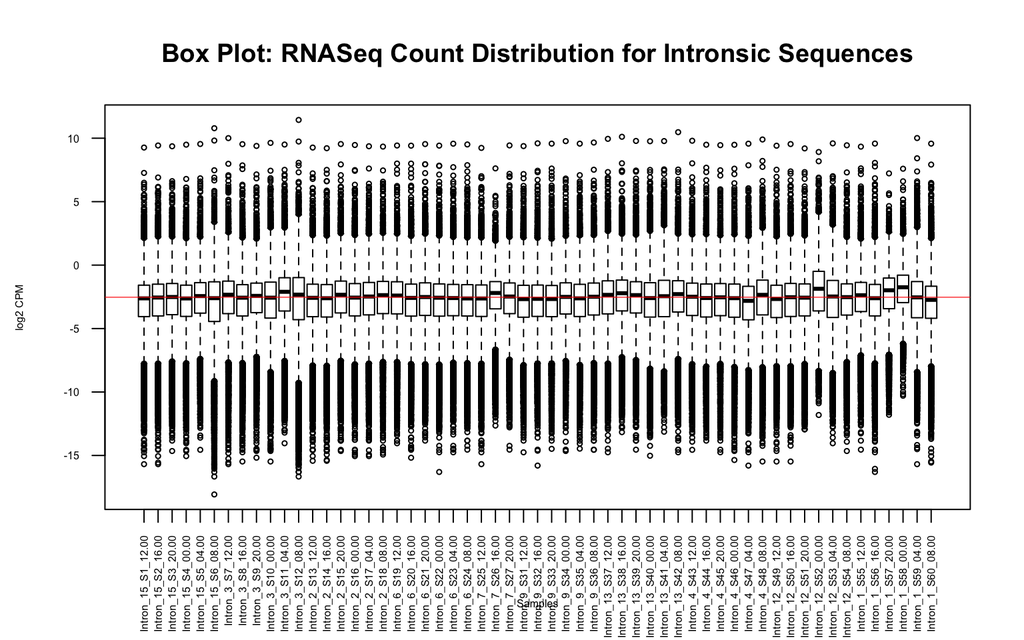

```r
plot_data = exp_data[, 2:115]
plot_data_intron <- exp_data[, 2:58]
plot_data_exon <- exp_data[, 59:115]

intron_plot <- boxplot(plot_data_intron, xlab = "Samples", ylab = "log2 CPM",
        las = 2, cex = 0.5, cex.lab = 0.5,
        cex.axis = 0.5, main = "Box Plot: RNASeq Count Distribution for Intronsic Sequences")
abline(h = median(apply(plot_data_intron, 2, median)), col = "red", lwd = 0.6, lty = "solid")
```

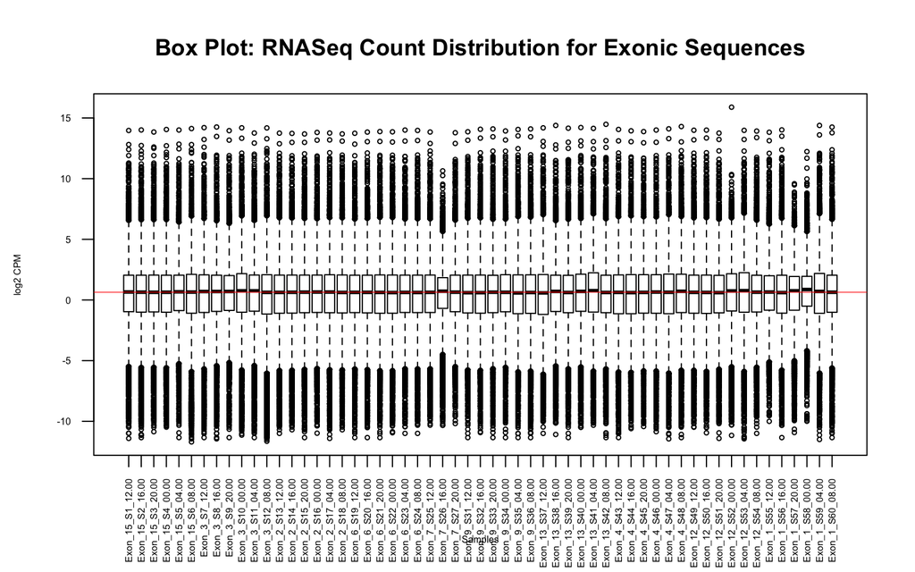

```r
boxplot(plot_data_exon, xlab = "Samples", ylab = "log2 CPM",
        las = 2, cex = 0.5, cex.lab = 0.5,
        cex.axis = 0.5, main = "Box Plot: RNASeq Count Distribution for Exonic Sequences") #CHANGE
abline(h = median(apply(plot_data_exon, 2, median)), col = "red", lwd = 0.6, lty = "solid")
```

Both box plots show us a very well normalized set of data. No outliers can be seen from this. A key difference to note here is the difference in medians between intron and exon sequences.

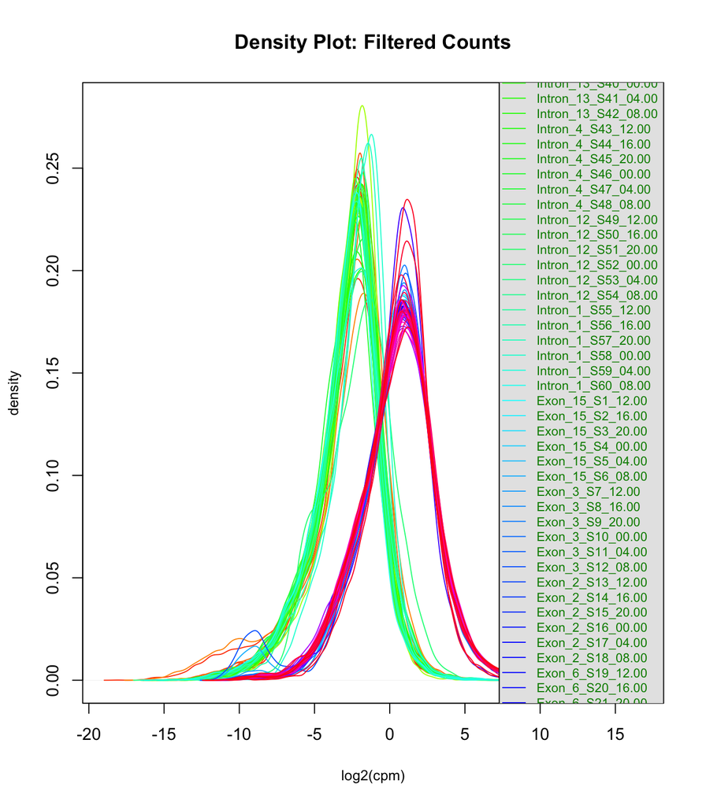

```r
counts_density <- apply(exp_data[, 2:115], 2, density)  #calculate the limits across all the samples
xlim <- 0; ylim <- 0
for (i in 1:length(counts_density)) {
  xlim <- range(c(xlim, counts_density[[i]]$x));
  ylim <- range(c(ylim, counts_density[[i]]$y))
}
cols <- rainbow(length(counts_density))
ltys <- rep(1, length(counts_density))
#plot the first density plot to initialize the plot
plot(counts_density[[1]], xlim=xlim, ylim=ylim, type="n",
     ylab="density", xlab="log2(cpm)", main="Density Plot: Filtered Counts", cex.lab = 0.85)
#plot each line
for (i in 1:length(counts_density)) lines(counts_density[[i]], col=cols[i], lty=ltys[i])
#create legend
legend("right", colnames(plot_data),
       col=cols, lty=ltys, cex=0.75,
       border ="blue",  text.col = "green4",
       merge = TRUE, bg = "gray90")
```

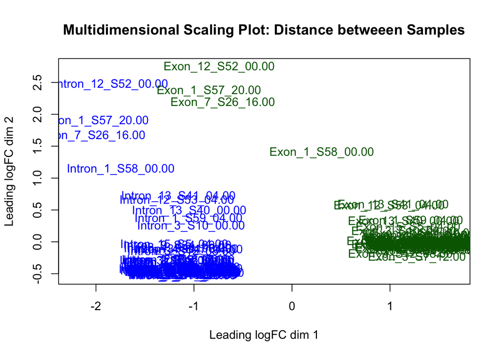

```r
filtered_data_matrix <- as.matrix(exp_data[,2:115])
# getting the inverse of the count values because the dataset was provided in log2 normalized counts
inverse_data_matrix <- apply(filtered_data_matrix, 2, function(x) 2^x)
rownames(inverse_data_matrix) <- exp_data$Gene_name
d = DGEList(counts=inverse_data_matrix, group=samples$sequence_type)
d = calcNormFactors(d)
normalized_counts <- cpm(d)

plotMDS(d, labels=rownames(samples),
        col = c("darkgreen","blue")[factor(samples$sequence_type)],
        main="Multidimensional Scaling Plot: Distance betweeen Samples")
```

From the MDS plot, overall we see the clustering of majority of intron and exon samples. The more interesting pattern is found when observed the samples that are not clustered with the others; we see the y-axis values are similar introns and exon samples with the same participants and time. Hence, there does not seem to be any significant outliers, and we will continue downstream analysis with all samples.

Next, we will show common vs tagwise dispersion. Dispersion measures the how much our counts deviate from the mean.

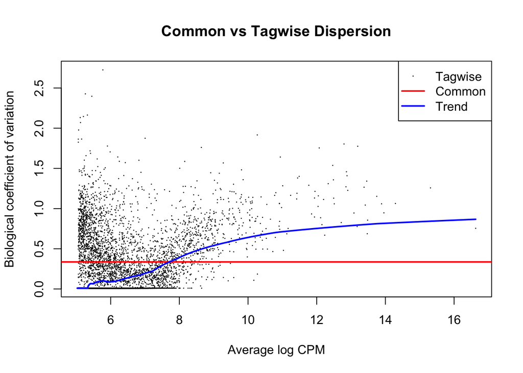

```r
d = DGEList(counts=inverse_data_matrix, group=samples$patients)
d = calcNormFactors(d)
normalized_counts <- cpm(d)
model_design <- model.matrix(~samples$patients)
d <- estimateDisp(d, model_design)
plotBCV(d,col.tagwise = "black",col.common = "red", main="Common vs Tagwise Dispersion")
```

This is not an expected or normal dispersion plot. Typically, the variance should decrease with increase in log CPM, but we have the opposite here. Investigation (reading paper, googling the issue, etc) to correct this was conducted but to no avail. Further investigation will be conducted to understand this.

Next, we will plot the mean and variance relationship.

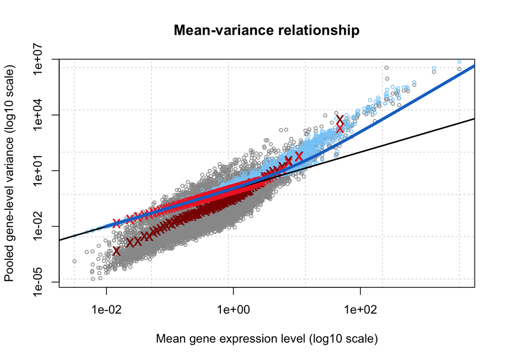

```r
plotMeanVar(d, show.raw.vars = TRUE, show.tagwise.vars=TRUE,
            show.ave.raw.vars = TRUE,
            NBline=TRUE,
            show.binned.common.disp.vars = TRUE,
            main="Mean-variance relationship",
            legend=TRUE)
```

# Identifier Mapping

Here we will get information on the identifier datasets and map the ensembl IDs to the current HUGO symbols:

```r
library(biomaRt)
listMarts()
```

```
##                biomart               version
## 1 ENSEMBL_MART_ENSEMBL      Ensembl Genes 99
## 2   ENSEMBL_MART_MOUSE      Mouse strains 99
## 3     ENSEMBL_MART_SNP  Ensembl Variation 99
## 4 ENSEMBL_MART_FUNCGEN Ensembl Regulation 99
```

```r
listEnsemblArchives()[1:10,]
```

```
##              name     date                                url version
## 1  Ensembl GRCh37 Feb 2014          http://grch37.ensembl.org  GRCh37
## 2      Ensembl 99 Jan 2020 http://jan2020.archive.ensembl.org      99
## 3      Ensembl 98 Sep 2019 http://sep2019.archive.ensembl.org      98
## 4      Ensembl 97 Jul 2019 http://jul2019.archive.ensembl.org      97
## 5      Ensembl 96 Apr 2019 http://apr2019.archive.ensembl.org      96
## 6      Ensembl 95 Jan 2019 http://jan2019.archive.ensembl.org      95
## 7      Ensembl 94 Oct 2018 http://oct2018.archive.ensembl.org      94
## 8      Ensembl 93 Jul 2018 http://jul2018.archive.ensembl.org      93
## 9      Ensembl 92 Apr 2018 http://apr2018.archive.ensembl.org      92
## 10     Ensembl 91 Dec 2017 http://dec2017.archive.ensembl.org      91
##    current_release
## 1
## 2                *
## 3
## 4
## 5
## 6
## 7
## 8
## 9
## 10
```

```r
ensembl <- useMart("ensembl")
datasets <- listDatasets(ensembl)
ensembl <- useDataset("hsapiens_gene_ensembl", mart=ensembl)
biomart_human_filters <- listFilters(ensembl)
biomart_human_filters[grep(biomart_human_filters$name,pattern="ensembl"),]
```

```
##                                   name
## 13       with_clone_based_ensembl_gene
## 14 with_clone_based_ensembl_transcript
## 55                     ensembl_gene_id
## 56             ensembl_gene_id_version
## 57               ensembl_transcript_id
## 58       ensembl_transcript_id_version
## 59                  ensembl_peptide_id
## 60          ensembl_peptide_id_version
## 61                     ensembl_exon_id
## 67            clone_based_ensembl_gene
## 68      clone_based_ensembl_transcript
##                                                         description
## 13                            With Clone-based (Ensembl) gene ID(s)
## 14                      With Clone-based (Ensembl) transcript ID(s)
## 55                         Gene stable ID(s) [e.g. ENSG00000000003]
## 56         Gene stable ID(s) with version [e.g. ENSG00000000003.15]
## 57                   Transcript stable ID(s) [e.g. ENST00000000233]
## 58   Transcript stable ID(s) with version [e.g. ENST00000000233.10]
## 59                      Protein stable ID(s) [e.g. ENSP00000000233]
## 60       Protein stable ID(s) with version [e.g. ENSP00000000233.5]
## 61                                Exon ID(s) [e.g. ENSE00000327880]
## 67           Clone-based (Ensembl) gene ID(s) [e.g. ABBA01000933.1]
## 68 Clone-based (Ensembl) transcript ID(s) [e.g. ABBA01000933.1-201]
```

```r
listAttributes(ensembl)[1:10,1:2]
```

```
##                             name                  description
## 1                ensembl_gene_id               Gene stable ID
## 2        ensembl_gene_id_version       Gene stable ID version
## 3          ensembl_transcript_id         Transcript stable ID
## 4  ensembl_transcript_id_version Transcript stable ID version
## 5             ensembl_peptide_id            Protein stable ID
## 6     ensembl_peptide_id_version    Protein stable ID version
## 7                ensembl_exon_id               Exon stable ID
## 8                    description             Gene description
## 9                chromosome_name     Chromosome/scaffold name
## 10                start_position              Gene start (bp)
```

```r
conversion_stash <- "gene_id_conversion.rds"

id_conversion <- getBM(attributes = c("ensembl_gene_id","hgnc_symbol"),
                          filters = c("ensembl_gene_id"),
                          values = exp_data$Gene_name,
                          mart = ensembl)
```

```
## Cache found
```

Here we see that there is ensembl_gene_id, exactly what we are looking for. We will use this to map the ensembl ids in our dataset.

Now that we have mapped the genes to HGNC symbols, we will check if there are any ensembl ids that have duplicate HGNC symbols:

```r
summarized_gene_counts <- sort(table(id_conversion$hgnc_symbol),decreasing = TRUE)
duplicated <- summarized_gene_counts[which(summarized_gene_counts>1)]
duplicated
```

```
##
##           ITFG2-AS1     PINX1   POLR2J4
##      1383         2         2         2
```

Hence, we have 3 genes that have duplicate mapping. Since this is a very small number relative to our overall database, we will not filter these out just yet.

The difference between number of mappings we found and number of genes in the normalized dataset is **148**

This number however does not tell the fully story. We will merge the mappings with the normalized dataset to get a better picture of the mapping.

```r
normalized_counts_annot <- merge(id_conversion, exp_data, by.x="ensembl_gene_id", by.y=1, all.y=TRUE)
normalized_counts_annot[1:8, 1:2]
```

```
##   ensembl_gene_id hgnc_symbol
## 1 ENSG00000000003      TSPAN6
## 2 ENSG00000000005        TNMD
## 3 ENSG00000000419        DPM1
## 4 ENSG00000000457       SCYL3
## 5 ENSG00000000460    C1orf112
## 6 ENSG00000000938         FGR
## 7 ENSG00000000971         CFH
## 8 ENSG00000001036       FUCA2
```

Based on our merged ensembl ids to HGNC symbols, we will identify the number of genes that did not match:

```r
ensembl_id_missing_gene <- normalized_counts_annot$ensembl_gene_id[
  which(is.na(normalized_counts_annot$hgnc_symbol))]
```

```r
ensembl_id_missing_list <- strsplit(ensembl_id_missing_gene, " ")
df <- data.frame(matrix(unlist(ensembl_id_missing_list),
                        nrow=length(ensembl_id_missing_gene), byrow=T))
colnames(df) <- c("ensembl_id")
mapped_genes <- nrow(exp_data) - length(ensembl_id_missing_gene) - length(duplicated) - 1

normalized_counts_annot_filtered <- normalized_counts_annot[
  which(!is.na(normalized_counts_annot$hgnc_symbol)), ]
```

## Questions

**What are the control and test conditions of the dataset?**  
The control condition was skeletal muscle biopsies collected from human samples who were placed under rigid laboratory conditions. Biopsies were taken every 4 hours across a 24 hour period from 10 individuals. The test conditions were performed on cultured human primary skeletal myotubes (hSKM). Though analyzing the cultered data analysis is beyond the scope of the course, there are several groups that the dataset can be clustered into (i.e. by demographic of timepoint) for differential analysis.

**Why is the dataset of interest to you?**  
I have been engaged in sleep research for the past few years at the level of physiological signals. Given my knowledge and previous experience in the sleep domain, exploring a dataset with biological signals related to sleep and circadian rhythms seemed quite fitting.

**Were there expression values that were not unique for specific genes? How did you handle these?** There were 3 values were each mapped to 2 genes. This is an insignificant amount of replication so we will simply filter both replications of these genes out in downstream analysis.

**How many outliers were removed?**  
No outliers were removed. There are some potential outliers shown in the MDS plot, but seem consistent enough to consider. We will keep all samples for now as they may reveal important insight in downstream analysis.

**How did you handle replicates?**  
There were no replicates in the dataset provided as it had already been cleaned prior to uploading to GEO.

## References

[1]L. Perrin et al., “Transcriptomic analyses reveal rhythmic and CLOCK-driven pathways in human skeletal muscle,” eLife, vol. 7, p. e34114, Apr. 2018, doi: 10.7554/eLife.34114.

[2]M. D. Robinson, D. J. McCarthy, and G. K. Smyth, “edgeR: a Bioconductor package for differential expression analysis of digital gene expression data,” Bioinformatics, vol. 26, no. 1, pp. 139–140, Jan. 2010, doi: 10.1093/bioinformatics/btp616.